# Countywide Update

Advancement Project California - We Count LA

# Overview of Response Rates

### Current Self-Response Rates as of 09/16

| State | County | HTC Census Tracts |
| --- | --- | --- |
| 68.4% | 63.7% | 57.7% |

## Response Rates Over Time

### State and County Self-Response Rates Over Time

- The USCB started publishing self-response rate data on 03/20/2020.
- While the state response rate is consistently about 4-5 percentage points above the county rate, both state and county rates have steadily increased throughout the self-response period.
- There has been an uptick in response rate increases over the past few weeks (09/01 to 09/16).
- The final self-response rate for California in 2010 was 68.2%, and the final 2010 rate for Los Angeles County was 69%.
- CA has surpassed its final 2010 self-response rate. LA County is approaching its 2010 self-response rate, and we continue to see steady increases in self-response for both despite challenges.

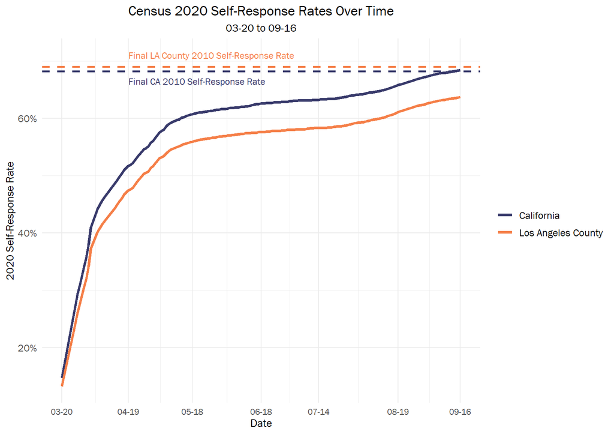

### Regional Self-Response Rates Over Time

- In LA County, the majority of hard-to-count census tracts have a lower response rate than the state rate and the county rate. However, we see a continuous creep upward in self-response rate, even in the regions with the largest concentration of HTC tracts.
- The hard work of CBOs doing Census outreach is reflected in the continuous, incremental increase in self-response rates.

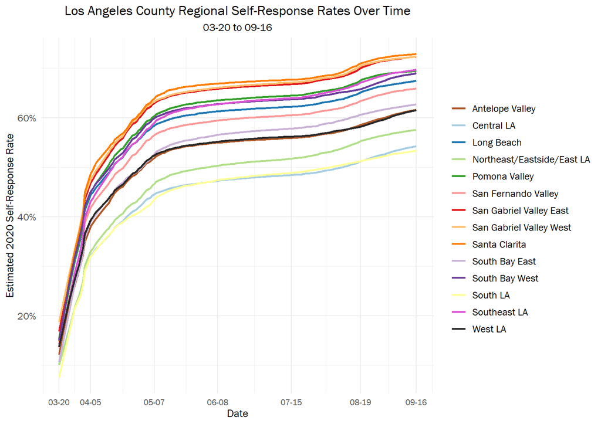

### Change Over Time: Data Table

The current response rates of the regions and the regional response rate increase over the past two weeks are summarized below.

| Region | Current Response Rate (09/16) | Difference 09/01 to 09/16 |
| --- | --- | --- |
| South LA | 53.4% | 1.0 |
| Central LA | 54.2% | 1.5 |
| Northeast/Eastside/East LA | 57.6% | 1.0 |
| West LA | 61.6% | 1.7 |
| Antelope Valley | 61.6% | 1.5 |
| South Bay East | 62.7% | 0.9 |
| San Fernando Valley | 65.9% | 1.0 |
| Long Beach | 67.5% | 1.0 |
| South Bay West | 69.0% | 1.4 |
| Pomona Valley | 69.5% | 0.6 |
| Southeast LA | 69.7% | 1.0 |
| San Gabriel Valley East | 72.4% | 0.7 |
| San Gabriel Valley West | 72.4% | 0.7 |
| Santa Clarita | 72.9% | 0.6 |

### Current Regional Self-Response Rates vs. 2010 Regional Rates

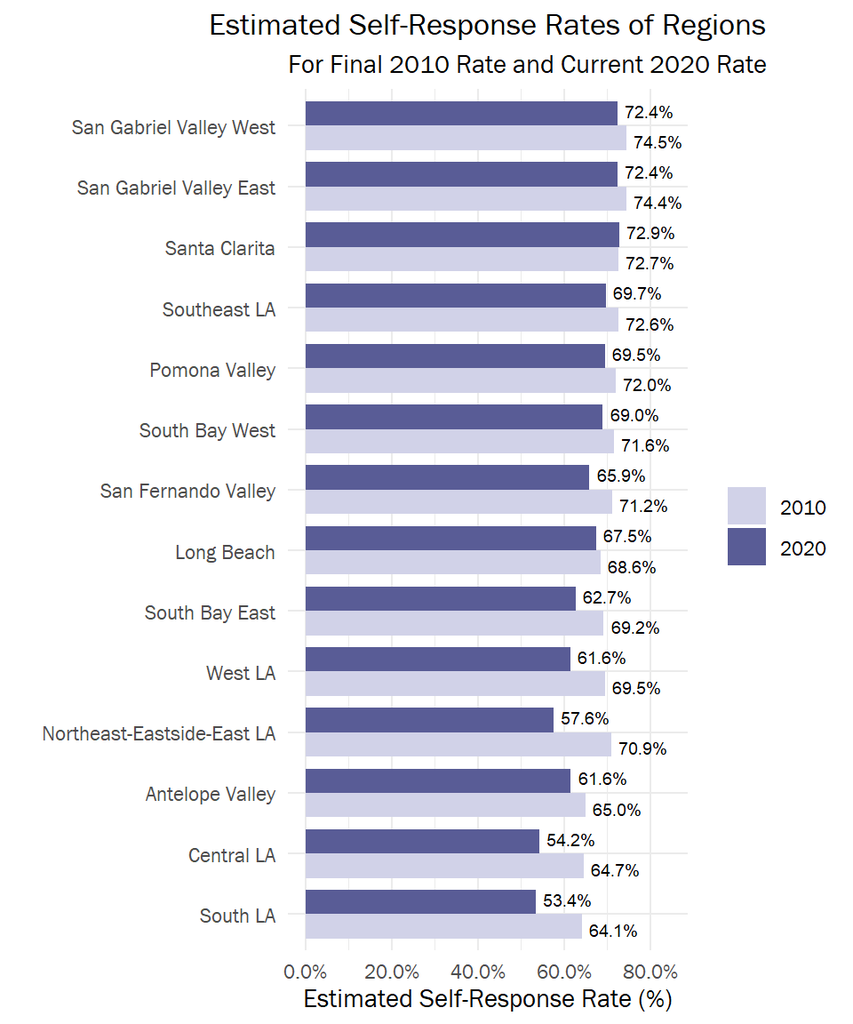

## Response Rate by Primary HTC Characteristic

#### All Census Tracts

- California Complete Count identifies the top hard-to-count (HTC) characteristic in each census tract.
- Looking at the top HTC characteristics in all census tracts, the most common top HTC characteristic is multi-unit structures, followed by foreign born population and crowded units.
- In census tracts where the top HTC characteristic is Households without broadband subscription, we see about 57.3% of households have responded so far. This is the current HTC group with the lowest response rate.

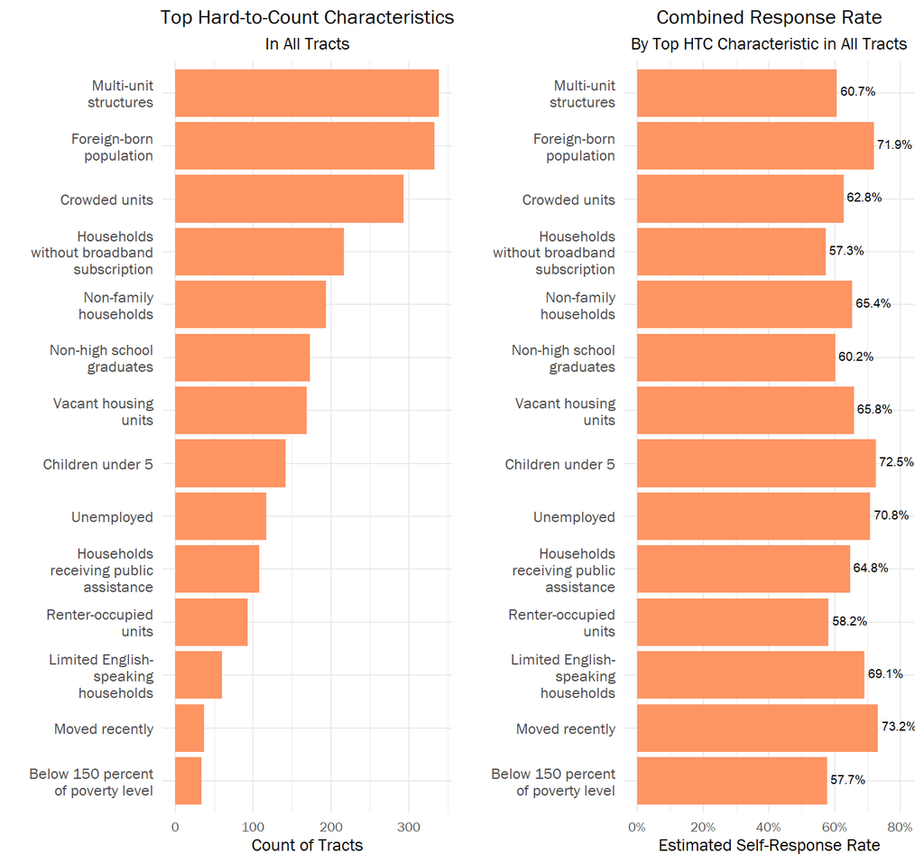

- **Urgent outreach priority:**
  - **Based on lowest response rates**, census tracts where the top HTC characteristic is: Households without broadband subscription, households Below 150 percent of poverty level and Renter-occupied units are the most urgent outreach priority.
  - **Based on highest number of uncounted households**, census tracts where the top HTC characteristic is: Multi-unit structures, Crowded units, and Foreign-born population.

### Countywide: Response Rate in Communities by Demographic

- **Data Note:** We do not have data on who is responding to the Census, we only know the number of households that have responded in each tract.
- For these plots, we identified the census tracts with a high share (highest quintile) of each demographic group. For example, in 20% of census tracts in LA County the tract population is 11.2% Black or higher. These tracts make up the top quintile of census tracts for the Black population. The quintile thresholds that define ‘top quintile’ tracts for other demographic groups are shown below.

#### Top Quintile Thresholds

- Census tracts where the AIAN population is greater than 1.1%
- Census tracts where the Asian population is greater than 21.9%
- Census tracts where the Black population is greater than 11.2%
- Census tracts where the Latinx population is greater than 77.8%
- Census tracts where the NHPI population is greater than 0.3%
- Census tracts where the Other/Two or More population is greater than 39.3%
- Census tracts where the White non-Latinx population is greater than 54.3%
- Census tracts where the foreign born population is greater than 45.5%
- Census tracts where the limited English proficient (LEP) population is greater than 37.3%

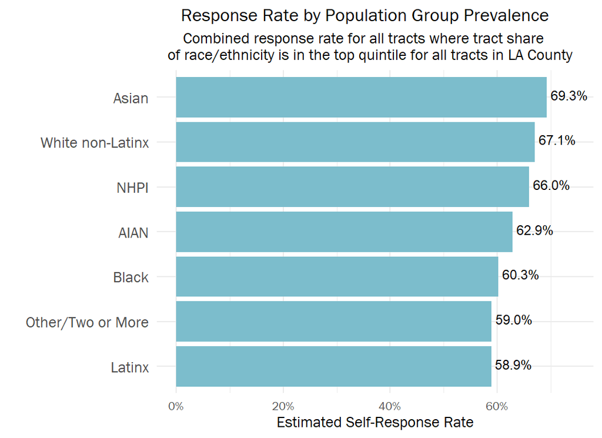

- The top 20% of census tracts for % Latinx population have a combined response rate of 58.9%. This is the lowest combined self-response rate in the county.
- The top 20% of census tracts for % Black population have a combined response rate of 60.3%.
- Communities with large Latinx and Black populations have a greater concentration of hard-to-count tracts, which is reflected in these response rate estimates.

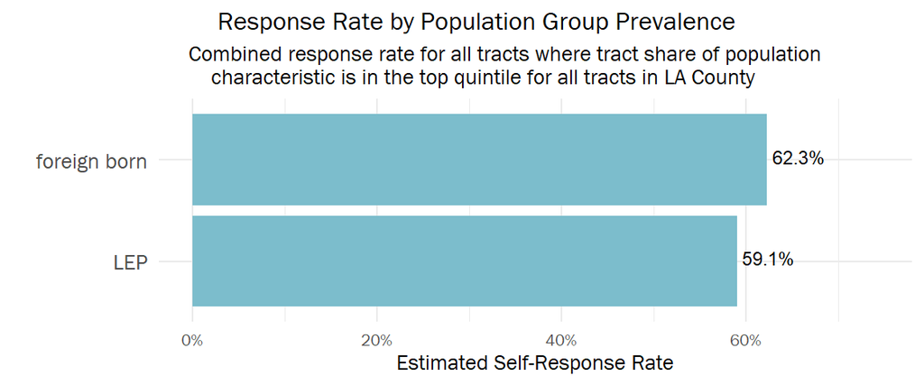

- In top 20% of census tracts for the Foreign Born population, the combined self-response rate is estimated to be 62.3%.
- In the top 20% of census tracts for the Language other than English population, the combined self-response rate is 59.1%.

# Outreach Priorities

Hard-to-count communities and regions with low response rates.

We recommend outreach time and resources be devoted to boosting response rates in these priority communities.

## Priority Communities by Demographics

Priority communities are determined by calculating the combined self-response rate for census tracts that are in the top quintile for various demographics (for example, the top 20% of limited English proficient census tracts). Census tracts where more than half of the population lives in group quarters have been excluded.

- Priority communities for targeting outreach to limited English proficient speakers & people born outside of the US are located in Central and South LA.
- These communities have low self-response rates in tracts where the share of LEP and foreign born populations are in the highest quintile.
- Central-Alameda, Historic South-Central and Pico-Union are priority communities for both people who don’t speak English well and for people who were born outside the US.

| Priority communities for LEP population |
| --- |
| Central-Alameda |
| Historic South-Central |
| Pico-Union |
| South Park |
| Watts |

| Priority communities for foreign born population |
| --- |
| Central-Alameda |
| Historic South-Central |
| Pico-Union |
| University Park |
| Vermont Square |

#### Priority communities by race/ethnicity

Many priority communities for targeting outreach to various demographic groups are located in South LA and Central LA, as these regions have the lowest overall self-response rates.

1. Central-Alameda and Historic South-Central in South LA are priority communities for Latinx and American Indian/Alaskan Native (AIAN) people living in low-responding tracts.
2. Downtown LA is a priority community for Black, Asian and Native Hawaiian/Pacific Islander (NHPI) populations living in low-responding tracts.
3. Pico-Union is a priority community for Asian, Latinx and American Indian/Alaskan Native (AIAN) people living in low-responding tracts.
4. Westlake is a priority community for Asian and NHPI populations.
5. Watts is a priority community for Black and Latinx populations.

| Priority communities for AIAN population |
| --- |
| Central-Alameda |
| Harvard Heights |
| Historic South-Central |
| Northeast Antelope Valley |
| Pico-Union |

| Priority communities for Asian population |
| --- |
| Downtown |
| Harvard Heights |
| Pico-Union |
| Westlake |
| Westwood |

| Priority communities for Black population |
| --- |
| Downtown |
| Hollywood |
| South Park |
| Watts |
| Westchester |

| Priority communities for Latinx population |
| --- |
| Central-Alameda |
| Florence |
| Historic South-Central |
| Pico-Union |
| Watts |

| Priority communities for NHPI population |
| --- |
| Boyle Heights |
| Downtown |
| Koreatown |
| Westlake |
| Wilmington |

## Priority Communities by Region

#### South LA-South Bay

| Region | Community | Top HTC Characteristic | Response Rate | Uncounted Households | Count of HTC Tracts in Community |
| --- | --- | --- | --- | --- | --- |
| South Bay East | East Compton | Non-high school graduates | 52.4% | 779 | 2 |
| South Bay East | Willowbrook | Non-high school graduates | 52.8% | 4,244 | 5 |
| South Bay East | Wilmington | Crowded units | 53.7% | 6,551 | 13 |
| South Bay East | Compton | Households receiving public assistance | 62.9% | 8,894 | 13 |
| South Bay West | Lennox | Non-high school graduates | 56.1% | 2,313 | 5 |
| South Bay West | Harbor Gateway | Crowded units | 61.2% | 4,818 | 7 |
| South Bay West | San Pedro | Unemployed | 61.9% | 11,870 | 10 |
| South Bay West | Inglewood | Multi-unit structures | 62.9% | 13,580 | 15 |
| South Bay West | Hawthorne | Renter-occupied units | 65% | 10,248 | 14 |
| South LA | Historic South-Central | Crowded units | 41.2% | 6,566 | 12 |
| South LA | Central-Alameda | Non-high school graduates | 45% | 5,416 | 10 |
| South LA | Watts | Non-high school graduates | 48.6% | 5,007 | 8 |
| South LA | Florence | Non-high school graduates | 49.5% | 6,338 | 13 |
| South LA | Florence-Firestone | Non-high school graduates | 53.2% | 7,248 | 14 |

#### Metro LA

| Region | Community | Top HTC Characteristic | Response Rate | Uncounted Households | Count of HTC Tracts in Community |
| --- | --- | --- | --- | --- | --- |
| Central LA | Downtown | Multi-unit structures | 40.4% | 16,868 | 13 |
| Central LA | Pico-Union | Renter-occupied units | 47.7% | 7,238 | 14 |
| Central LA | Hollywood | Renter-occupied units | 49.2% | 19,492 | 21 |
| Central LA | Westlake | Multi-unit structures | 50.5% | 18,872 | 29 |
| Central LA | Koreatown | Multi-unit structures | 55.6% | 18,234 | 30 |
| Northeast-Eastside-East LA | Lincoln Heights | Limited English-speaking households | 51.7% | 3,529 | 6 |
| Northeast-Eastside-East LA | Boyle Heights | Households without broadband subscription | 53% | 11,468 | 25 |
| Northeast-Eastside-East LA | El Sereno | Households without broadband subscription | 56.3% | 5,048 | 6 |
| Northeast-Eastside-East LA | Highland Park | Unemployed | 57.6% | 7,033 | 7 |
| Northeast-Eastside-East LA | East Los Angeles | Non-high school graduates | 60.2% | 12,228 | 26 |
| West LA | Westwood | Non-family households | 49% | 9,503 | 5 |
| West LA | Pico-Robertson | Non-family households | 55.7% | 3,669 | 2 |
| West LA | Palms | Multi-unit structures | 64.5% | 7,587 | 2 |

#### AV-SC

| Region | Community | Top HTC Characteristic | Response Rate | Uncounted Households | Count of HTC Tracts in Community |
| --- | --- | --- | --- | --- | --- |
| Antelope Valley | Lancaster | Below 150 percent of poverty level | 62.2% | 18,012 | 9 |
| Antelope Valley | Palmdale | Non-high school graduates | 63.4% | 16,064 | 9 |
| Santa Clarita | Santa Clarita | Multi-unit structures | 73.6% | 17,842 | 3 |

#### SFV

| Region | Community | Top HTC Characteristic | Response Rate | Uncounted Households | Count of HTC Tracts in Community |
| --- | --- | --- | --- | --- | --- |
| San Fernando Valley | Pacoima | Non-high school graduates | 56.4% | 8,033 | 16 |
| San Fernando Valley | Van Nuys | Multi-unit structures | 58.1% | 14,681 | 24 |
| San Fernando Valley | North Hollywood | Multi-unit structures | 59.2% | 12,217 | 18 |
| San Fernando Valley | Sun Valley | Foreign-born population | 59.8% | 7,708 | 10 |
| San Fernando Valley | Canoga Park | Multi-unit structures | 60.7% | 8,565 | 10 |
| San Fernando Valley | Glendale | Foreign-born population | 71.2% | 21,275 | 23 |

#### Long Beach

| Region | Community | Top HTC Characteristic | Response Rate | Uncounted Households | Count of HTC Tracts in Community |
| --- | --- | --- | --- | --- | --- |
| Long Beach | Washington | Renter-occupied units | 54.5% | 1,008 | 2 |
| Long Beach | Downtown/Central | Renter-occupied units | 55.4% | 1,358 | 2 |
| Long Beach | AOC7 | Crowded units | 56.9% | 1,763 | 3 |
| Long Beach | Wilmore | Multi-unit structures | 57.4% | 3,345 | 5 |
| Long Beach | Cambodia Town | Crowded units | 59.9% | 2,098 | 4 |

#### SELA

| Region | Community | Top HTC Characteristic | Response Rate | Uncounted Households | Count of HTC Tracts in Community |
| --- | --- | --- | --- | --- | --- |
| Southeast LA | Huntington Park | Crowded units | 58.9% | 5,991 | 17 |
| Southeast LA | Lynwood | Non-high school graduates | 61.6% | 5,979 | 10 |
| Southeast LA | Paramount | Non-high school graduates | 63.6% | 5,261 | 8 |
| Southeast LA | Bell Gardens | Non-high school graduates | 63.9% | 3,488 | 9 |
| Southeast LA | South Gate | Non-high school graduates | 67% | 7,896 | 17 |

#### SGV-Pomona

| Region | Community | Top HTC Characteristic | Response Rate | Uncounted Households | Count of HTC Tracts in Community |
| --- | --- | --- | --- | --- | --- |
| Pomona Valley | Pomona | Non-high school graduates | 63.8% | 14,162 | 15 |
| San Gabriel Valley East | South San Jose Hills | Non-high school graduates | 60.8% | 2,044 | 2 |
| San Gabriel Valley East | La Puente | Non-high school graduates | 68.7% | 2,917 | 3 |
| San Gabriel Valley East | Baldwin Park | Foreign-born population | 72.7% | 4,876 | 5 |
| San Gabriel Valley West | South El Monte | Households without broadband subscription | 62.9% | 1,915 | 4 |
| San Gabriel Valley West | El Monte | Foreign-born population | 66% | 10,052 | 20 |
| San Gabriel Valley West | Rosemead | Limited English-speaking households | 72.5% | 4,046 | 5 |
| San Gabriel Valley West | Alhambra | Foreign-born population | 75.3% | 7,268 | 8 |

## About We Count LA

[Advancement Project California](https://www.advancementprojectca.org/) partnered with the California Community Foundation to convene the [We Count LA](https://wecountla.org/) Census Table. Under one brand and one mission, to secure a fair and accurate count of all Angelenos, the We Count LA Census Table brings together community-based organizations and other census stakeholders (philanthropy, state/local government, business) to share resources and coordinate planned activities across the region and particularly in high-need census tracts.

[figure not shown]

Published by [Advancement Project California](https://www.advancementprojectca.org/)

[figure not shown]